# CS107 Final Project

Vidya Bhalodia

April 14, 2016

[output not shown]

Volume of Visits in the survey from 2007 - 2011.

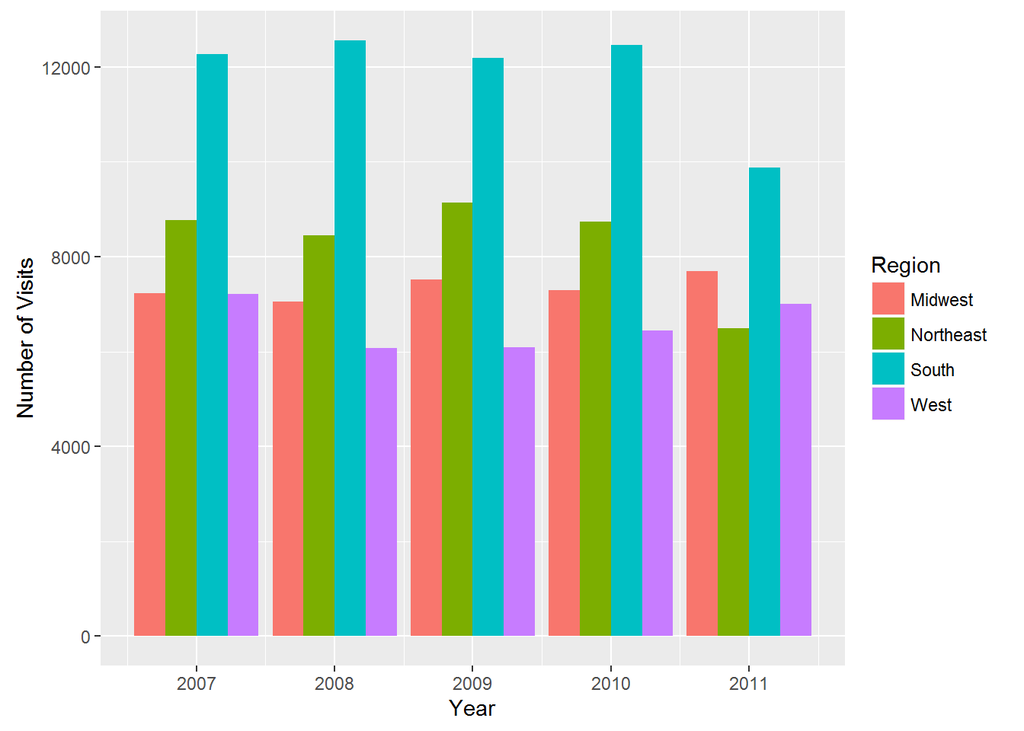

While it may seem that the number of ER visits surveyed dropped markedly in 2011 from 35k to 31k, overview of all the survey data in the series shows a high of 40k cases documented in 2003, to a low of ~21k in 1999.

# ER Ownership

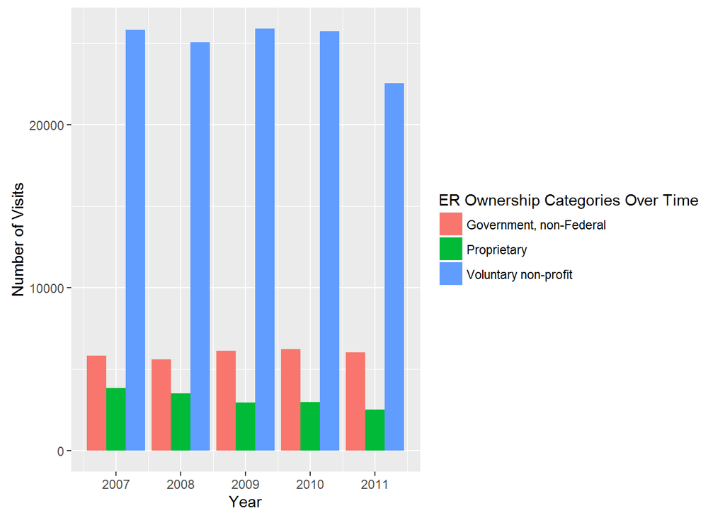

We can see that the vast majority of ER visits are consistently to volunteer/non-profit facilities.

# Insurance

```
## Source: local data frame [2 x 3]
##
##   SexCategory NumVisits PercentVisits
##        (fctr)     (int)         (dbl)
## 1      Female     92388            54
## 2        Male     78198            46
```

The US census reports that the population is 50.8% women. Women were more likely than men to visit the ER (54%) Using the central limit theorem, mu = 0.508, sd = sqrt(p*(1-p)/n), giving us a Zscore of 29-sigma. It’s safe to say that this finding is significant based on our data. This finding has been corroborated by other studies : “http://www.cdc.gov/nchs/data/nhsr/nhsr090.pdf”

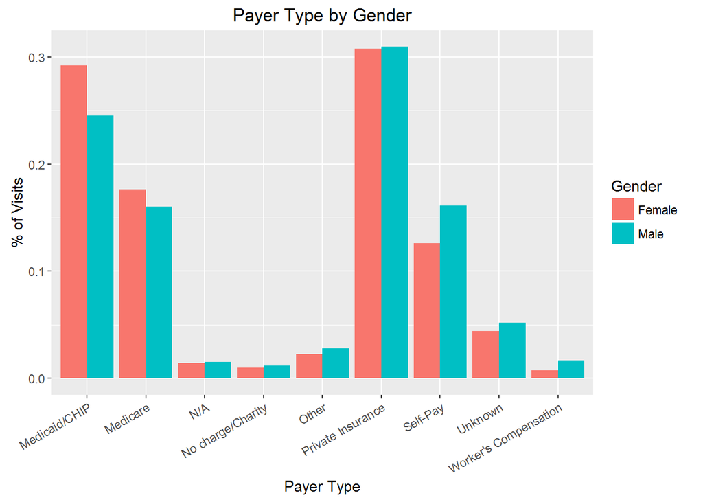

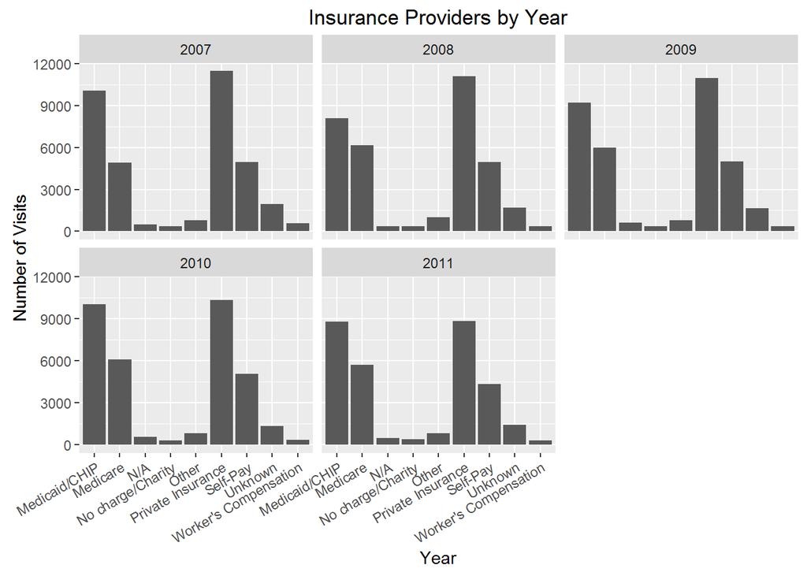

# Race and Ethnicity

We will look at the race and ethnicity of patients presenting to the ER. For the purposes of this analysis, we will exclude the 9% of patients who chose to have both race and ethnicity defined as N/A.

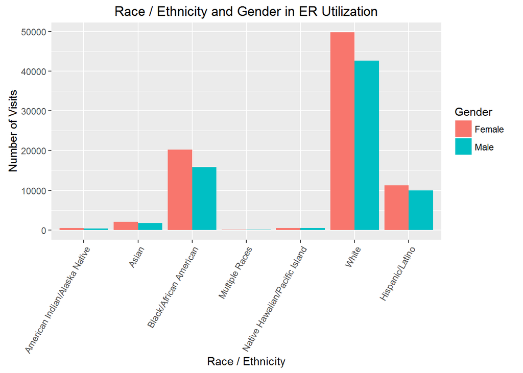

| RaceCategory | NumVisits | PercentVisits | PopulationPercentage | Zscore |
| --- | --- | --- | --- | --- |
| American Indian/Alaska Native | 909 | 0.5328691 | 0.9 | -15.33364 |
| Asian | 3823 | 2.2410983 | 4.8 | -47.21685 |
| Black/African American | 36037 | 21.1254147 | 12.6 | 101.33442 |
| Multiple Races | 259 | 0.1518296 | 2.9 | -64.59777 |
| Native Hawaiian/Pacific Island | 911 | 0.5340415 | 0.2 | 29.49189 |
| White | 92407 | 54.1703305 | 72.4 | -160.85606 |
| Hispanic/Latino | 21238 | 12.4500252 | 16.3 | -41.11344 |

Globally we can see that Blacks/African Americans are close to 2x as likely to visit the ER than other races, while Caucasian(White) and Asians are less likely. Though these findings are significant, they are is confounded by the large percentage of patients in this survey who chose not to identify their race and/or ethnicity (not shown).

Across all races/ethnicities, more women than men tended to use ER services. While there have been a number of studies performed on race and ethnicity based utilization of the ER, far less work has been done on gender related differences. In our further analyses, we will take closer looks at how ER services are utilized by gender.

# Age

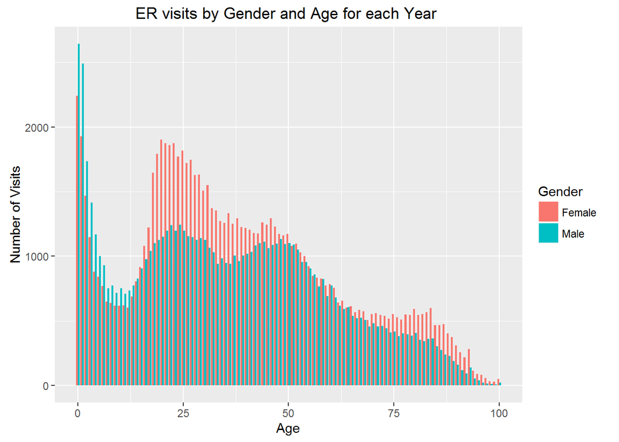

Unsurprisingly, young children make up a large fraction of emergency room visits due to their susceptibility to illness and propensity for injury. What I find surprising is that there is such a dramatic difference in ER utilization in women vs men from ages 19 - 50. The discrepancy in ER utilization in the oldest age ranges (>70) is probably due to the difference in longevity between men and women (more elderly women tend to use the ER than elderly men in this in part because women simply make up a significantly larger fraction of the population at those ages).

# Diagnosis and Primary Complaints

| describeDiagnosis | NumVisits |
| --- | --- |
| Symptoms involving respiratory system and other chest symptoms | 8471 |
| General symptoms | 7772 |
| Other symptoms involving abdomen and pelvis | 7379 |
| Unspecified transport accident | 3969 |
| Other and unspecified disorders of back | 3730 |
| Other cellulitis and abscess | 3722 |

It looks like the top 5 reasons for visiting the ER are : “trouble breathing”, “not feeling good”, “abdominal / tummy problems”, “vehicular accident”, “back problems”, “pus and infection”.

The diagnosis codes that physicians use when billing weren’t as useful to understanding patient visits as I’d hoped. I’m going to look at “reasons for visit” which represents what the patient reports as their complaint when coming to the emergency room.

# Chief Complaint

Now we are looking at the patient’s chief complaints when they come to the ER. There are literally hundreds of general reasons (and thousands of specific ones) to visit the ER - we will keep things simple and restrict it to reasons that each make up 2% (or more) of total ER visits

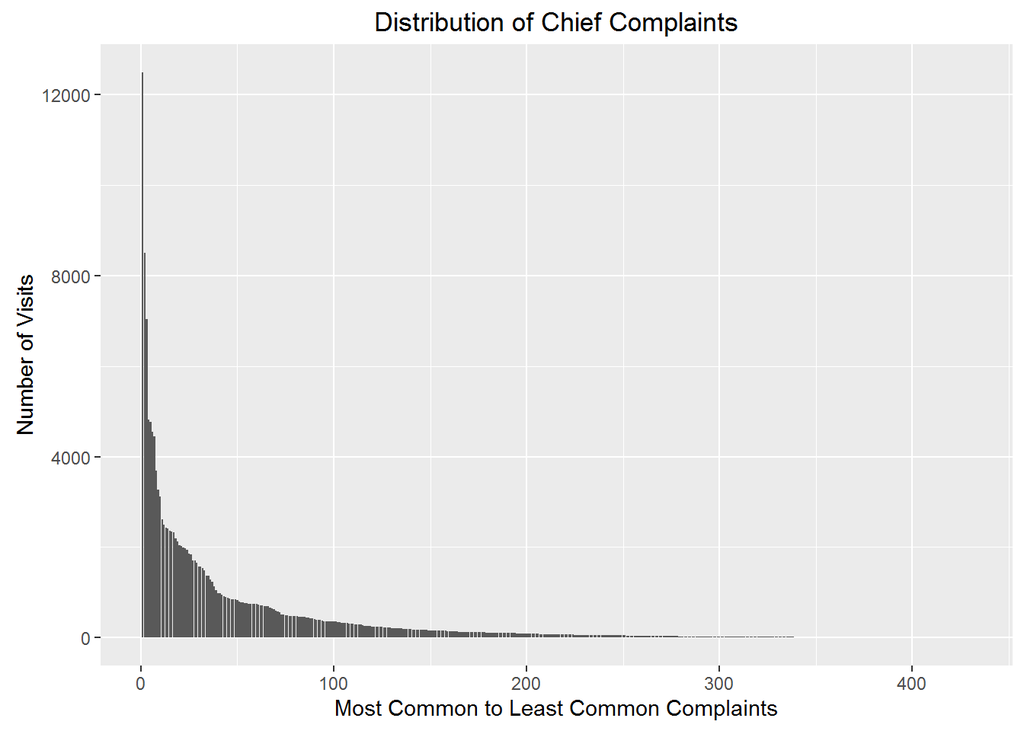

As you can see, a very small number of complaints make up the vast majority of ER visits, while the long tail tells us that a lot chief complaints in the ER are rare (appearing only once or twice). Now let’s take a look at the gender distribution of the top 10 complaints

| RFV13D | NumVisits | RFV.description | frequencyRank |
| --- | --- | --- | --- |
| 1545 | 12500 | Stomach and abdominal pain, cramps an… | 1 |
| 1050 | 8497 | Chest pain and related symptoms (not … | 2 |
| 1010 | 7044 | Fever | 3 |
| 1210 | 4819 | Headache, pain in head | 4 |
| 1440 | 4772 | Cough | 5 |
| 1905 | 4543 | Back symptoms | 6 |
| 1415 | 4446 | Shortness of breath | 7 |
| 1055 | 3694 | Pain, site not referable to a specifi… | 8 |
| 1530 | 3264 | Vomiting | 9 |
| 1455 | 3109 | Symptoms referable to throat | 10 |

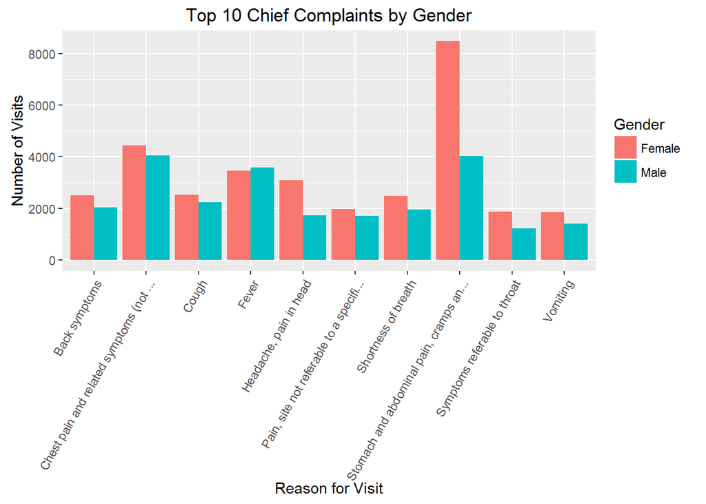

Now let’s look at the top 10 reasons for women to visit the ER

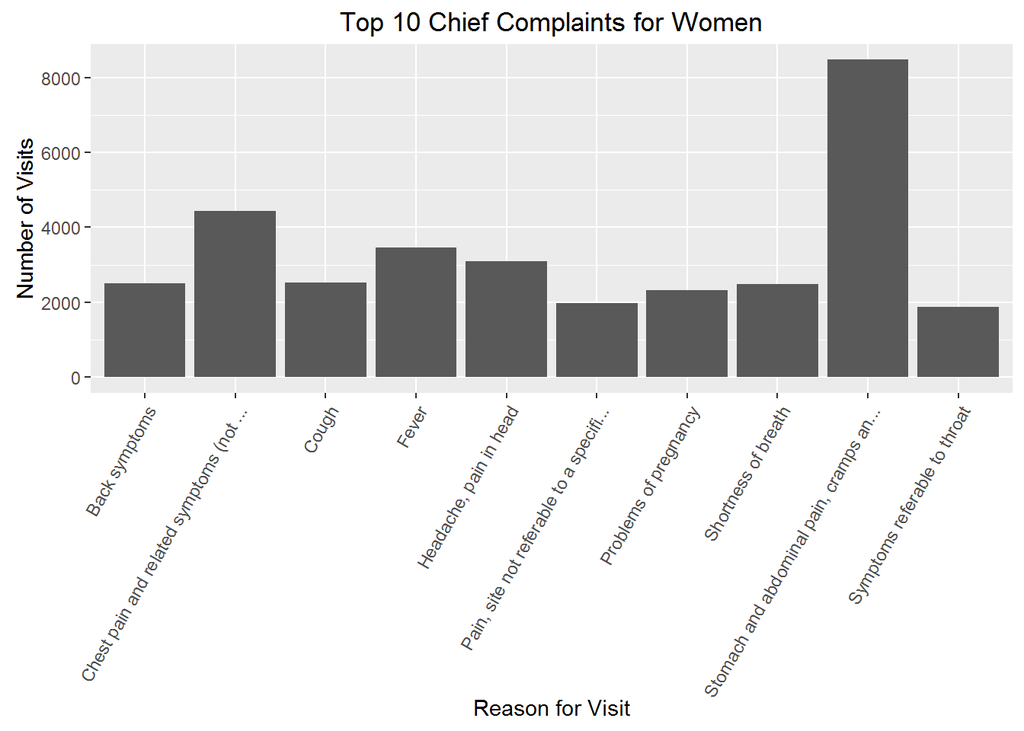

Now let’s look at the top 10 reasons for men to visit the ER

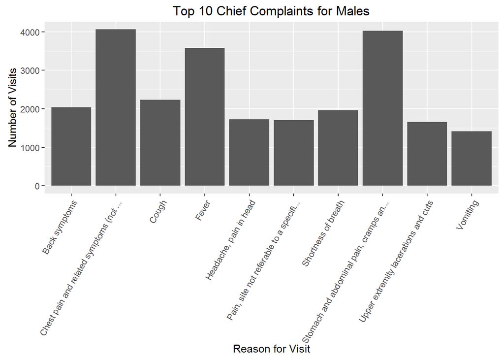

When looking at female specific complaints, it’s no surprise that problems of pregnancy are one of the top 10 reasons for ER visits (obviously this would not be a health issue that affects males). For males, cuts/injuries to the upper extremities (arms/shoulders) is on the top 10 list, while it ranks 46th in reasons for women.

# Race / Ethnicity and Chief Complaint

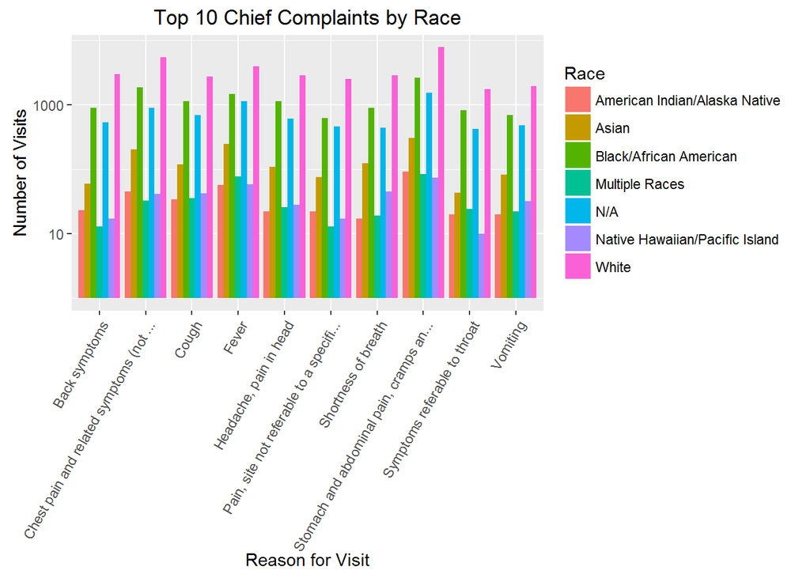

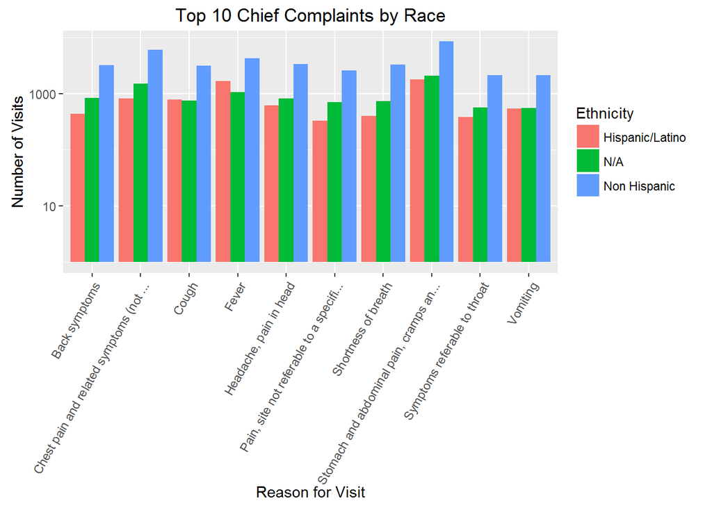

| RFV.description | Asian | Black/African American | White | Hispanic/Latino |
| --- | --- | --- | --- | --- |
| Back symptoms | NA | 0.0246211 | 0.0282423 | 0.0207176 |
| Chest pain and related symptoms (not … | 0.0527541 | 0.0509202 | 0.0511808 | 0.0388926 |
| Cough | 0.0305146 | 0.0311408 | 0.0256422 | 0.0377154 |
| Earache, or ear infection | NA | NA | NA | 0.0210472 |
| Fever | 0.0641324 | 0.0404115 | 0.0375590 | 0.0797627 |
| Headache, pain in head | 0.0279286 | 0.0315535 | 0.0271118 | 0.0297109 |
| Pain, site not referable to a specifi… | 0.0196535 | NA | 0.0234944 | NA |
| Problems of pregnancy | 0.0305146 | 0.0185139 | NA | 0.0274037 |
| Shortness of breath | 0.0318076 | 0.0247861 | 0.0272814 | NA |
| Skin rash | NA | NA | NA | 0.0197759 |
| Stomach and abdominal pain, cramps an… | 0.0796483 | 0.0717449 | 0.0734223 | 0.0854129 |
| Symptoms referable to throat | NA | 0.0225853 | 0.0166175 | NA |
| Vertigo - dizziness | 0.0222395 | NA | NA | NA |
| Vomiting | 0.0214637 | 0.0189816 | 0.0182849 | 0.0257557 |

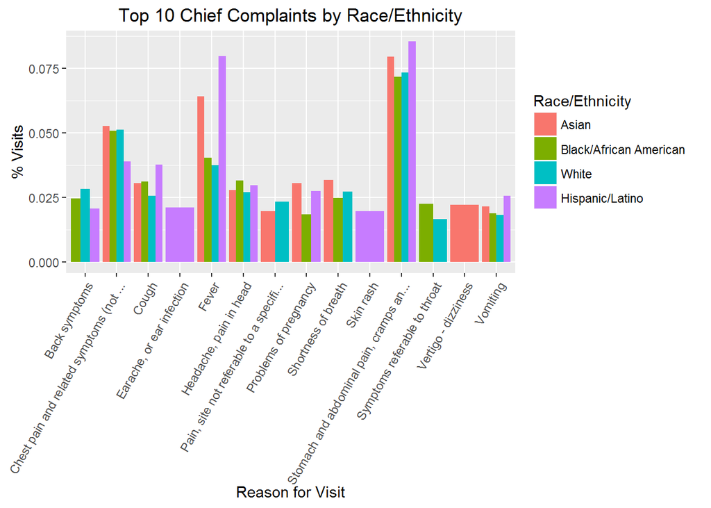

So based on this, it looks like patients of different racial groups are more/less likely to present to the ER with certain complaints. For example, Hispanics are more likely to present to the ER with ear complaints or skin rashes, while Whites are less likely to present to the ER with pregnancy related problems.

# Relationships between Age and Gender and Diagnoses.

Earlier we saw that the ratio between female and male ER patients changed as function of age. Now we want to see how the diagnoses change with age and gender. We will limit the analyses to the top 12 most common complaints (as defined by the join of top 10 for females, males and combined)

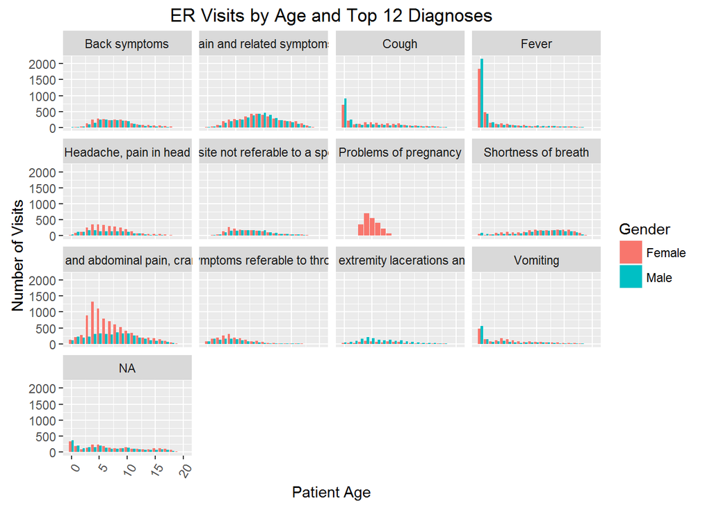

# Most Frequent Complaints for By Gender and Age Range.

| AgeCategory | RFV.description | AgeRange | Female | Male |
| --- | --- | --- | --- | --- |
| 0 | Fever | 0 - 5 | 1839 | 2146 |
| 1 | Fever | 5 - 10 | 477 | 432 |
| 2 | Stomach and abdominal pain, cramps an… | 10 - 15 | 283 | 193 |
| 3 | Stomach and abdominal pain, cramps an… | 15 - 20 | 897 | 236 |
| 4 | Stomach and abdominal pain, cramps an… | 20 - 25 | 1326 | 305 |
| 5 | Stomach and abdominal pain, cramps an… | 25 - 30 | 1105 | 333 |
| 6 | Stomach and abdominal pain, cramps an… | 30 - 35 | 794 | 314 |
| 7 | Chest pain and related symptoms (not … | 35 - 40 | NA | 310 |
| 7 | Stomach and abdominal pain, cramps an… | 35 - 40 | 709 | NA |
| 8 | Chest pain and related symptoms (not … | 40 - 45 | NA | 384 |
| 8 | Stomach and abdominal pain, cramps an… | 40 - 45 | 601 | NA |
| 9 | Chest pain and related symptoms (not … | 45 - 50 | NA | 429 |
| 9 | Stomach and abdominal pain, cramps an… | 45 - 50 | 528 | NA |
| 10 | Chest pain and related symptoms (not … | 50 - 55 | NA | 455 |
| 10 | Stomach and abdominal pain, cramps an… | 50 - 55 | 412 | NA |
| 11 | Chest pain and related symptoms (not … | 55 - 60 | 345 | 395 |
| 12 | Chest pain and related symptoms (not … | 60 - 65 | 276 | 300 |
| 13 | Chest pain and related symptoms (not … | 65 - 70 | 238 | 234 |
| 14 | Chest pain and related symptoms (not … | 70 - 75 | 215 | 198 |
| 15 | Chest pain and related symptoms (not … | 75 - 80 | 205 | 164 |
| 16 | Chest pain and related symptoms (not … | 80 - 85 | 202 | NA |
| 16 | Shortness of breath | 80 - 85 | NA | 140 |
| 17 | Shortness of breath | 85 - 90 | 142 | 98 |
| 18 | Hip symptoms | 90 - 95 | 41 | NA |
| 18 | Shortness of breath | 90 - 95 | 97 | 41 |
| 19 | General weakness | 95 - 100 | 23 | 10 |
| 20 | Accident, NOS | 100 - 105 | 4 | NA |
| 20 | Breathing problems, NEC | 100 - 105 | 2 | NA |
| 20 | Fever | 100 - 105 | NA | 2 |
| 20 | Head, neck, and face injury, type uns… | 100 - 105 | 2 | NA |
| 20 | Headache, pain in head | 100 - 105 | NA | 2 |
| 20 | Hip symptoms | 100 - 105 | 2 | NA |
| 20 | Oth sympt/prob relat psychological an… | 100 - 105 | 2 | NA |
| 20 | Progress visit, NOS | 100 - 105 | 2 | NA |
| 20 | Shoulder symptoms | 100 - 105 | 2 | NA |
| 20 | Stomach and abdominal pain, cramps an… | 100 - 105 | 4 | NA |
| 20 | Unconscious on arrival | 100 - 105 | 2 | NA |
| 20 | Uterine and vaginal bleeding | 100 - 105 | 2 | NA |

# Arriving the ER via EMS

Now we want to look at the experience surrounding patients coming to the ER and the services they get there. Let’s look at the fraction of patients who arrive by ambulance.

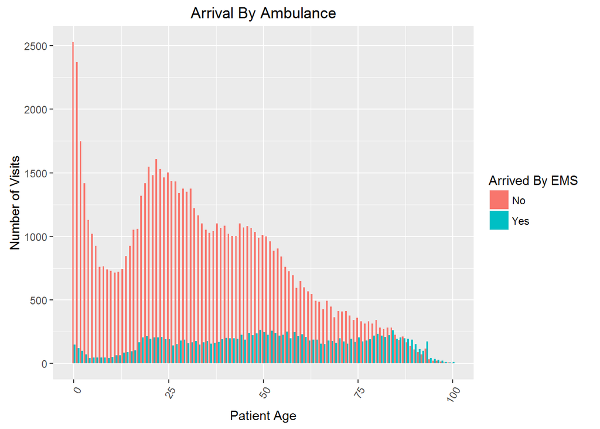

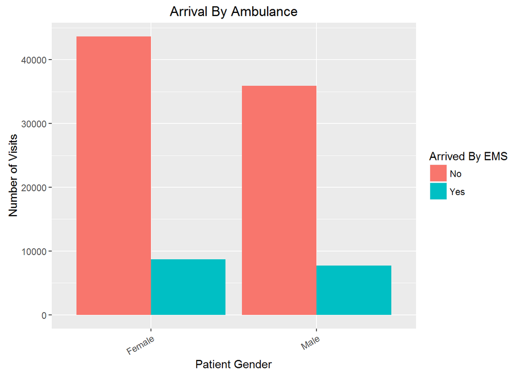

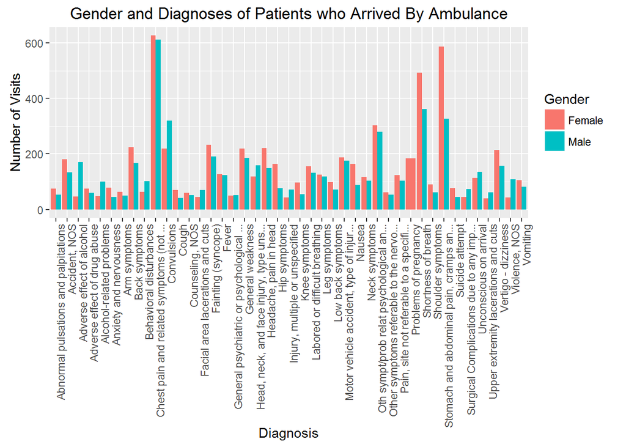

Overall more women than men were brought in via ambulance - consistent with more women than men utilizing the ER in general. However, for many but not all common diagnoses - specifically for complaints involving alcohol use, violence, convulsions/seizures, unconsciousness, and lacerations/injuries, men were more likely than women to arrive via ambulance.

Let’s compare the fraction of patients of each gender who are brought in by ambulance.

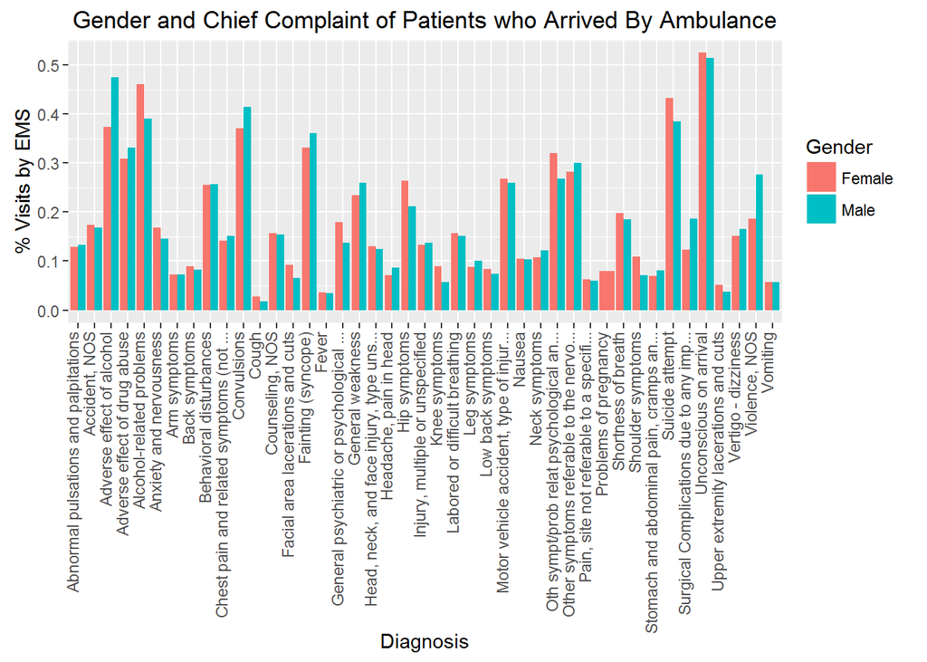

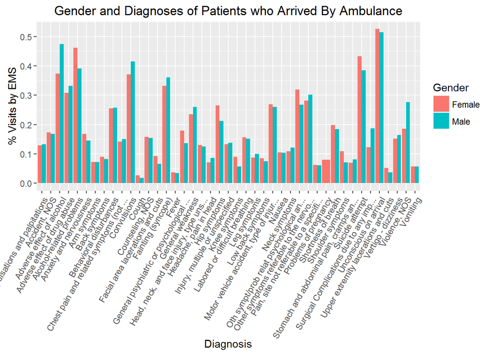

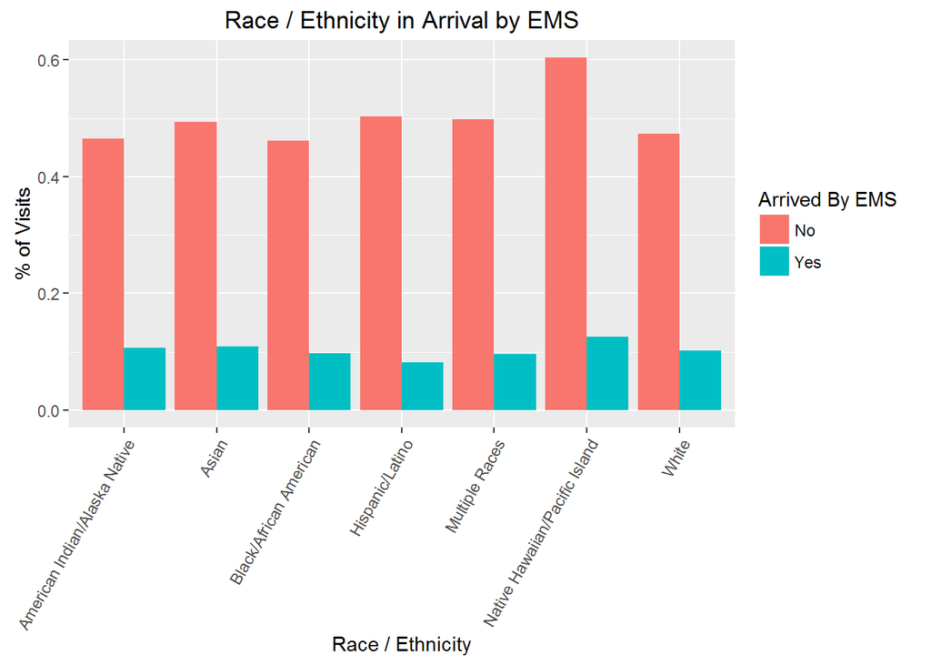

# Wait times and Length of Visit.

For the purposes of our analyses, we are going to choose the top 12 most common diagnoses for adult men/women (age > 18) and look at the wait times / length of visit times involved.

# Wait Time

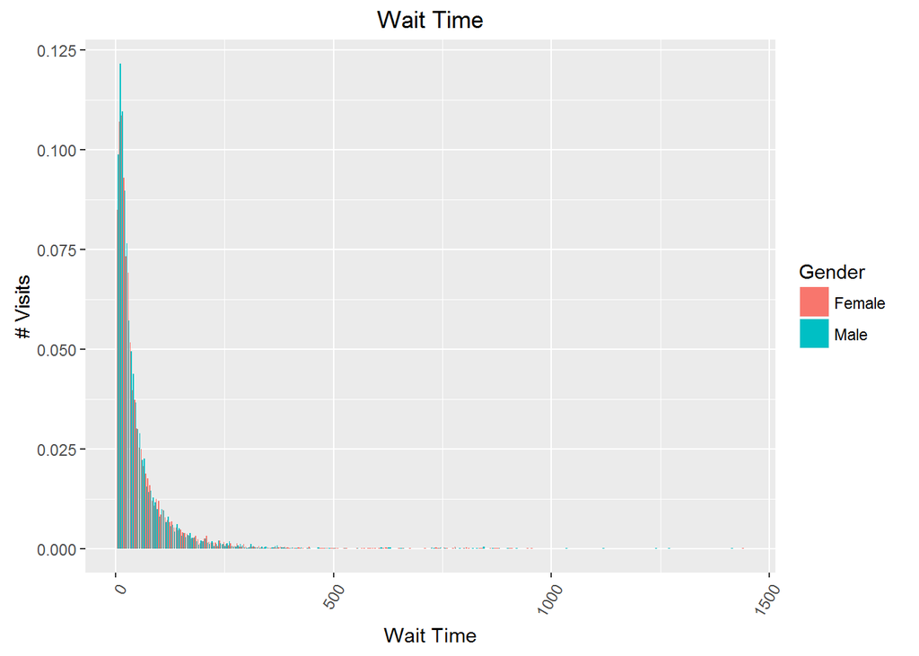

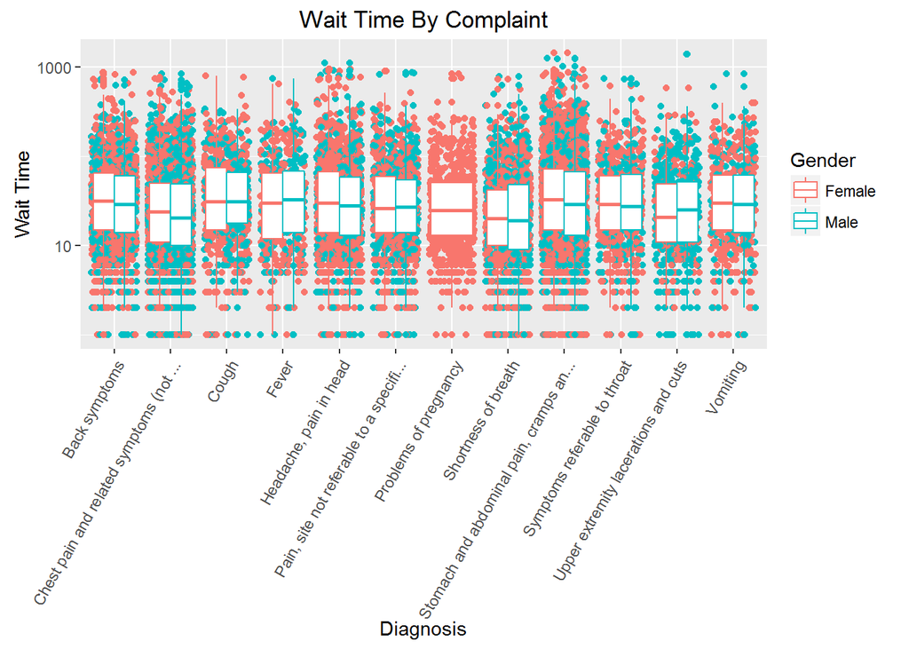

| RFV.description | MeanWaitMale | MedianWaitMale | MeanWaitFemale | MedianWaitFemale | pValue |
| --- | --- | --- | --- | --- | --- |
| Back symptoms | 48.72460 | 29.0 | 58.80450 | 31.5 | 0.0109364788649134 |
| Chest pain and related symptoms (not … | 43.10769 | 20.5 | 43.56163 | 24.0 | 0.861447835511864 |
| Cough | 51.13313 | 31.0 | 56.63694 | 31.0 | 0.243443614364794 |
| Fever | 54.41284 | 33.0 | 53.21405 | 30.0 | 0.852108565676535 |
| Headache, pain in head | 58.76063 | 28.0 | 60.96008 | 30.0 | 0.72258928580132 |
| Pain, site not referable to a specifi… | 49.60653 | 27.0 | 49.31202 | 26.0 | 0.94670178253984 |
| Shortness of breath | 41.87609 | 19.0 | 37.80896 | 20.0 | 0.253015560981222 |
| Stomach and abdominal pain, cramps an… | 60.04358 | 29.0 | 61.17101 | 33.0 | 0.729838346694388 |
| Symptoms referable to throat | 56.54132 | 27.5 | 49.25166 | 29.0 | 0.266531727411951 |
| Upper extremity lacerations and cuts | 43.29412 | 25.5 | 44.34759 | 21.0 | 0.86122175779292 |
| Vomiting | 55.66667 | 29.0 | 50.20107 | 30.0 | 0.444724414069235 |
| Problems of pregnancy | NA | NA | 44.98440 | 25.0 | NA |

We performed a 2 tailed t-test on wait times by gender for each symptom. The only complaint where there was a statistically difference between genders, was for back symptoms. The significance in this case may be mitigated by the fact that we were making multiple comparisons.

# Length of Visit

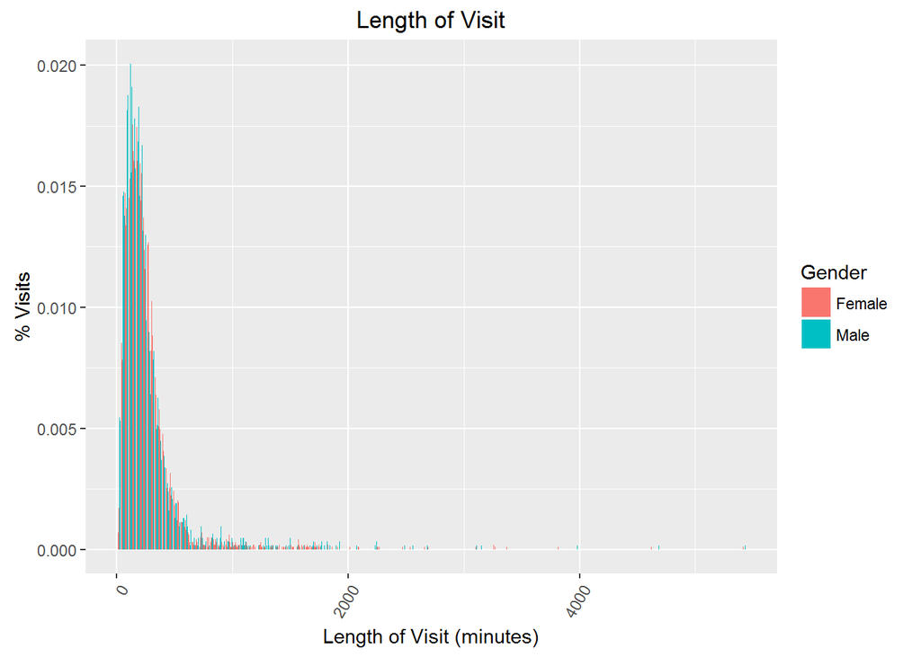

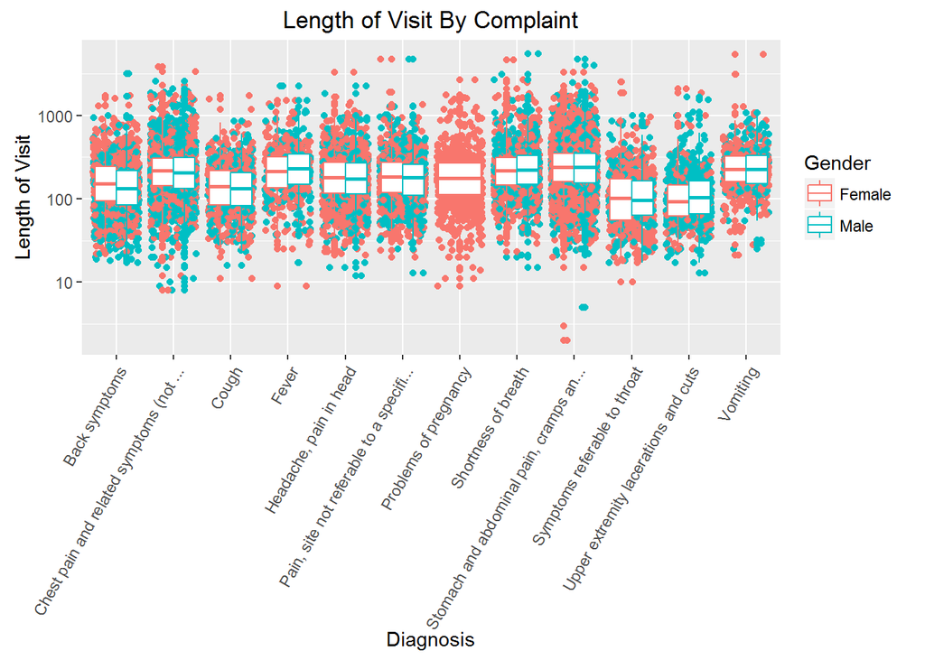

| RFV.description | MeanLOVtMale | MedianLOVMale | MeanLOVFemale | MedianLOVFemale | pValue |
| --- | --- | --- | --- | --- | --- |
| Back symptoms | 172.3829 | 133.0 | 195.4668 | 150.5 | 0.010317304243247 |
| Chest pain and related symptoms (not … | 261.4092 | 205.5 | 265.4478 | 217.0 | 0.666221871203514 |
| Cough | 160.9102 | 132.0 | 178.4904 | 142.0 | 0.0699105685287803 |
| Fever | 305.3303 | 229.5 | 262.7726 | 212.0 | 0.0725183975114968 |
| Headache, pain in head | 223.5235 | 173.0 | 225.1801 | 181.0 | 0.885175468204244 |
| Pain, site not referable to a specifi… | 223.4587 | 180.0 | 225.5373 | 182.0 | 0.888162873797968 |
| Shortness of breath | 289.4904 | 223.0 | 287.2227 | 219.0 | 0.900361338826035 |
| Stomach and abdominal pain, cramps an… | 297.9651 | 240.0 | 290.3261 | 239.0 | 0.40431201953352 |
| Symptoms referable to throat | 146.6364 | 96.5 | 143.7461 | 101.0 | 0.824427016283618 |
| Upper extremity lacerations and cuts | 143.0168 | 104.0 | 146.1604 | 93.0 | 0.86381930508409 |
| Vomiting | 275.4479 | 225.5 | 276.8740 | 228.0 | 0.948534624068604 |
| Problems of pregnancy | NA | NA | 230.3021 | 178.0 | NA |

Aside from patients presenting with back symptoms where females tended to have longer visits than males, there does not seem to be any systematic or statistically significant gender-based differences in length of visit times for ER patients.

# Number of Medications Administered

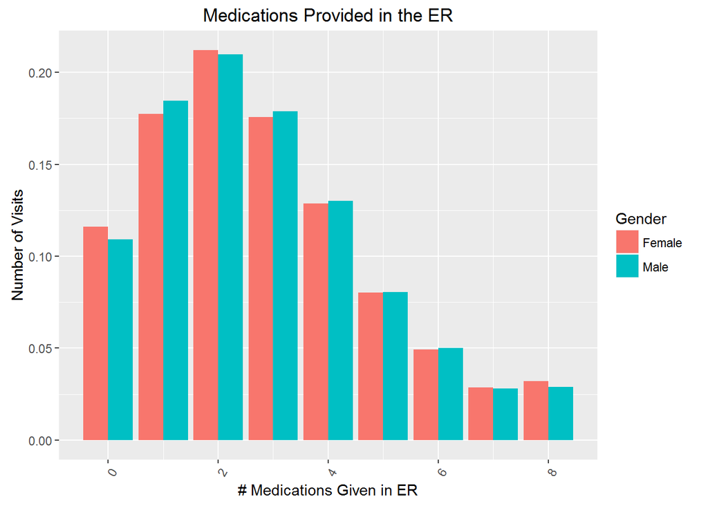

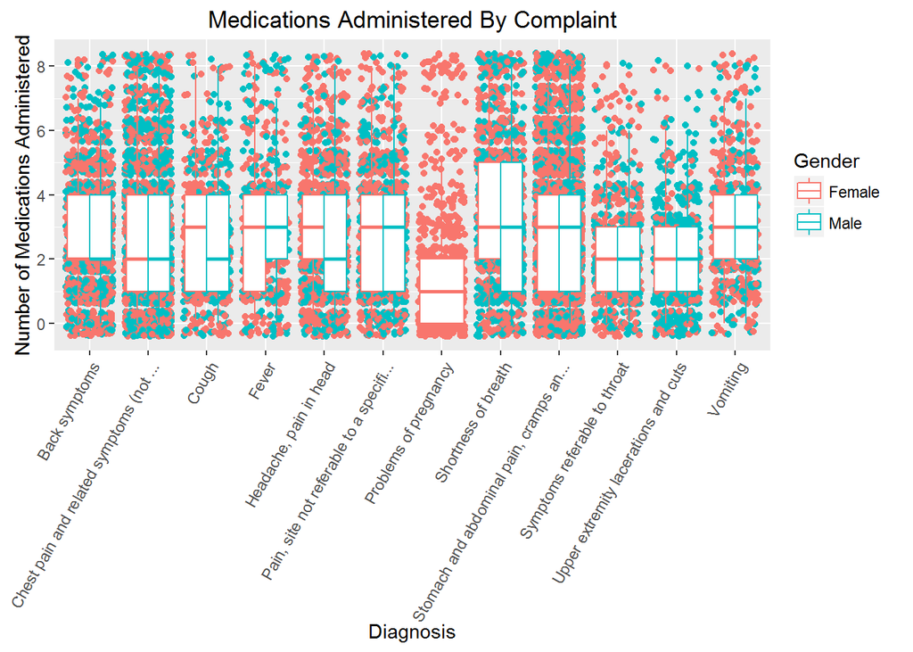

| RFV.description | MeanMedstMale | MedianMedsMale | MeanMedsFemale | MedianMedsFemale |
| --- | --- | --- | --- | --- |
| Back symptoms | 2.782032 | 2 | 2.747630 | 2 |
| Chest pain and related symptoms (not … | 2.690769 | 2 | 2.671772 | 2 |
| Cough | 2.705882 | 2 | 2.683652 | 3 |
| Fever | 3.298165 | 3 | 2.943144 | 3 |
| Headache, pain in head | 2.583893 | 2 | 2.937564 | 3 |
| Pain, site not referable to a specifi… | 2.737044 | 3 | 2.911720 | 3 |
| Shortness of breath | 3.139616 | 3 | 3.254282 | 3 |
| Stomach and abdominal pain, cramps an… | 3.042789 | 3 | 3.018478 | 3 |
| Symptoms referable to throat | 2.342975 | 2 | 2.331126 | 2 |
| Upper extremity lacerations and cuts | 2.153361 | 2 | 1.989305 | 2 |
| Vomiting | 3.182292 | 3 | 3.182306 | 3 |
| Problems of pregnancy | NA | NA | 1.757447 | 1 |

There does not seem to be any systematic gender-based differences in number of medications administered to ER patients. While some complaints (eg pregancy problems) had fewer medicines administered than others (shortness of breath), the high variability meant that none of these differences were statistically significant.

# Number of Diagnostic Tests Performed

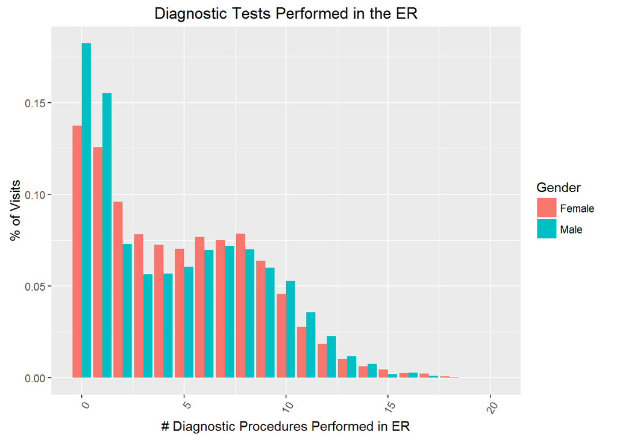

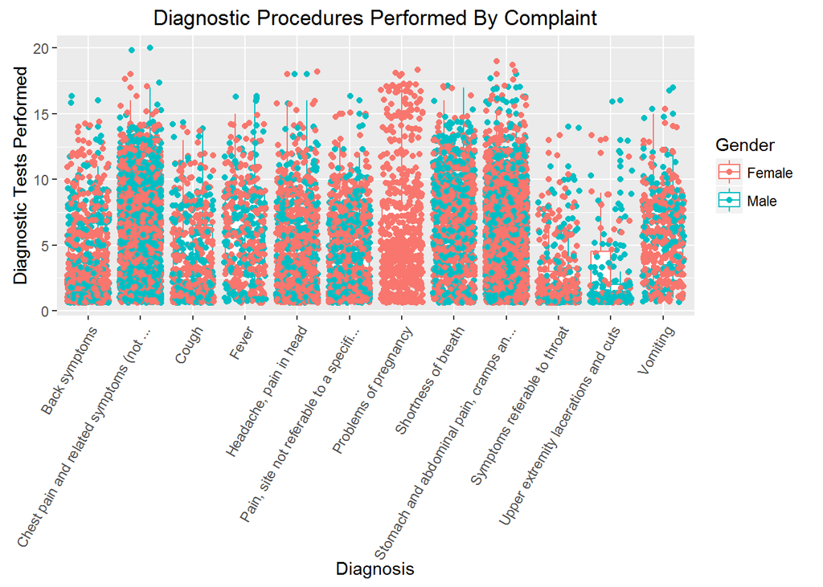

| RFV.description | MeanDiagstMale | MedianDiagsMale | MeanDiagsFemale | MedianDiagsFemale |
| --- | --- | --- | --- | --- |
| Back symptoms | 1.8995502 | 1.0 | 2.480144 | 1 |
| Chest pain and related symptoms (not … | 6.8247104 | 7.0 | 6.808029 | 7 |
| Cough | 2.9347826 | 1.0 | 2.778495 | 1 |
| Fever | 5.5275229 | 5.5 | 5.338926 | 5 |
| Headache, pain in head | 3.4237668 | 2.0 | 3.165631 | 2 |
| Pain, site not referable to a specifi… | 3.4547206 | 2.0 | 4.283970 | 4 |
| Shortness of breath | 6.8917976 | 7.0 | 6.355820 | 7 |
| Stomach and abdominal pain, cramps an… | 5.7292994 | 6.0 | 5.638414 | 6 |
| Symptoms referable to throat | 1.5062762 | 1.0 | 1.442953 | 1 |
| Upper extremity lacerations and cuts | 0.8004292 | 0.0 | 1.000000 | 0 |
| Vomiting | 5.6596859 | 6.0 | 5.447439 | 6 |
| Problems of pregnancy | NA | NA | 5.073969 | 4 |

# Procedures Performed

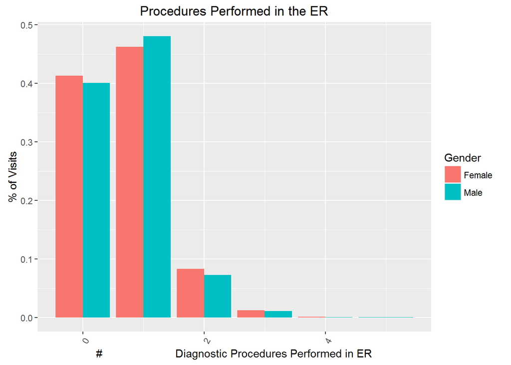

[figure not shown]

| RFV.description | MeanProcsMale | MedianProcsMale | MeanProcsFemale | MedianProcsFemale |
| --- | --- | --- | --- | --- |
| Back symptoms | 0.2739726 | 0 | 0.3119605 | 0 |
| Chest pain and related symptoms (not … | 0.6813804 | 1 | 0.6664157 | 1 |
| Cough | 0.5000000 | 0 | 0.4646018 | 0 |
| Fever | 0.8476190 | 1 | 0.7559322 | 1 |
| Headache, pain in head | 0.5242494 | 0 | 0.5453575 | 0 |
| Pain, site not referable to a specifi… | 0.5110220 | 0 | 0.5996860 | 1 |
| Shortness of breath | 1.0072333 | 1 | 1.0378378 | 1 |
| Stomach and abdominal pain, cramps an… | 0.7755102 | 1 | 0.8049052 | 1 |
| Symptoms referable to throat | 0.2304348 | 0 | 0.2222222 | 0 |
| Upper extremity lacerations and cuts | 1.1957447 | 1 | 1.0432432 | 1 |
| Vomiting | 0.9358289 | 1 | 0.9078591 | 1 |
| Problems of pregnancy | NA | NA | 0.8318841 | 1 |

There does not seem to be any systematic gender-based differences in number of procedures performed on ER patients. The one exception to this was women who presented with certain uncategorized pain symptoms - who had a median of 1 procedure performed, while men had a median of 0 procedures.

# LOV vs Number of Medications

Now we will look at the relationship between length of visit and various treatments in the ER (medicines administered, diagnostic tests run, procedures performed)

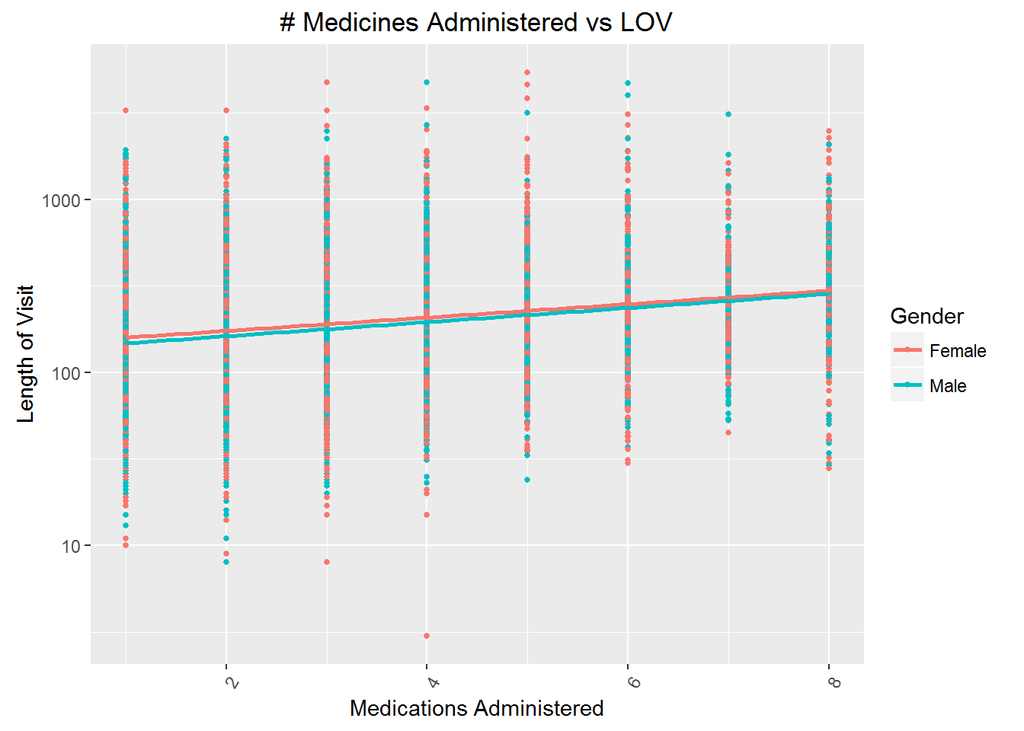

```
##
## Call:
## lm(formula = log(LOV) ~ NUMMED, data = .)
##
## Residuals:
##     Min      1Q  Median      3Q     Max
## -4.3226 -0.4268  0.0298  0.4422  3.2068
##
## Coefficients:
##             Estimate Std. Error t value Pr(>|t|)
## (Intercept) 5.015706   0.012237  409.89   <2e-16 ***
## NUMMED      0.080927   0.003547   22.81   <2e-16 ***
## ---
## Signif. codes:  0 '***' 0.001 '**' 0.01 '*' 0.05 '.' 0.1 ' ' 1
##
## Residual standard error: 0.7112 on 9854 degrees of freedom
## Multiple R-squared:  0.05017,    Adjusted R-squared:  0.05007
## F-statistic: 520.5 on 1 and 9854 DF,  p-value: < 2.2e-16
```

```
##
## Call:
## lm(formula = log(LOV) ~ NUMMED, data = .)
##
## Residuals:
##     Min      1Q  Median      3Q     Max
## -3.3470 -0.4566  0.0295  0.4681  3.2396
##
## Coefficients:
##             Estimate Std. Error t value Pr(>|t|)
## (Intercept) 4.956446   0.016270  304.65   <2e-16 ***
## NUMMED      0.080762   0.004745   17.02   <2e-16 ***
## ---
## Signif. codes:  0 '***' 0.001 '**' 0.01 '*' 0.05 '.' 0.1 ' ' 1
##
## Residual standard error: 0.7456 on 6231 degrees of freedom
## Multiple R-squared:  0.04443,    Adjusted R-squared:  0.04428
## F-statistic: 289.7 on 1 and 6231 DF,  p-value: < 2.2e-16
```

For both genders, each additional medication administered in the OR is correlated with an ~8% increase in length of visit. This correlation is statistically significant but weak - with an R^2 of only 0.04

# LOV vs Number of Diagnostic Tests

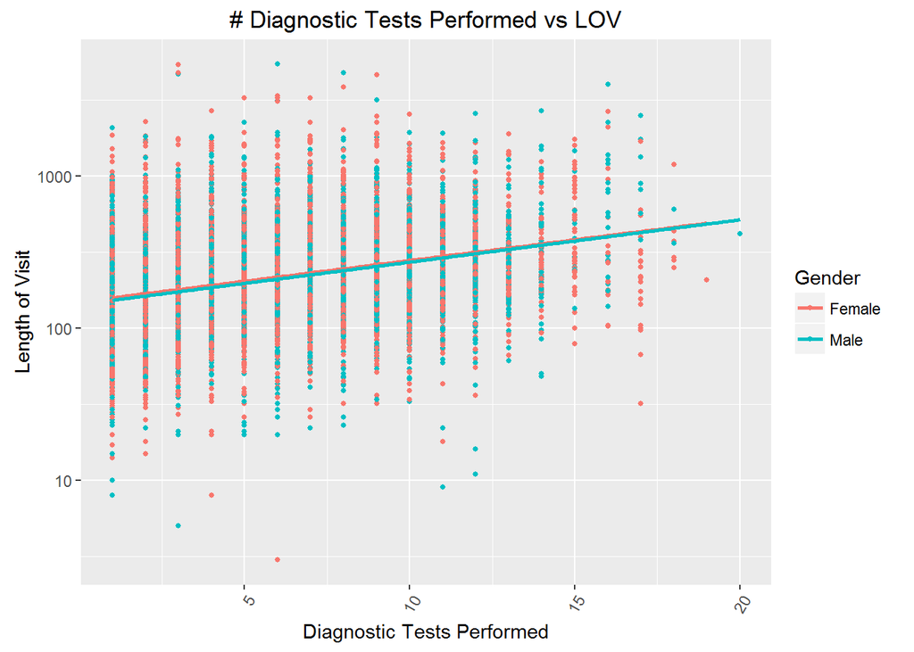

```
##
## Call:
## lm(formula = log(LOV) ~ TOTDIAG, data = .)
##
## Residuals:
##     Min      1Q  Median      3Q     Max
## -4.2453 -0.3995  0.0085  0.3940  3.4871
##
## Coefficients:
##             Estimate Std. Error t value Pr(>|t|)
## (Intercept)  4.87431    0.01041  468.41   <2e-16 ***
## TOTDIAG      0.07826    0.00170   46.03   <2e-16 ***
## ---
## Signif. codes:  0 '***' 0.001 '**' 0.01 '*' 0.05 '.' 0.1 ' ' 1
##
## Residual standard error: 0.662 on 9854 degrees of freedom
## Multiple R-squared:  0.177,  Adjusted R-squared:  0.1769
## F-statistic:  2119 on 1 and 9854 DF,  p-value: < 2.2e-16
```

```
##
## Call:
## lm(formula = log(LOV) ~ TOTDIAG, data = .)
##
## Residuals:
##     Min      1Q  Median      3Q     Max
## -3.5131 -0.4174  0.0012  0.4033  3.3936
##
## Coefficients:
##             Estimate Std. Error t value Pr(>|t|)
## (Intercept) 4.813560   0.012903  373.05   <2e-16 ***
## TOTDIAG     0.081524   0.002113   38.58   <2e-16 ***
## ---
## Signif. codes:  0 '***' 0.001 '**' 0.01 '*' 0.05 '.' 0.1 ' ' 1
##
## Residual standard error: 0.6852 on 6231 degrees of freedom
## Multiple R-squared:  0.1928, Adjusted R-squared:  0.1927
## F-statistic:  1489 on 1 and 6231 DF,  p-value: < 2.2e-16
```

For both genders, each additional diagnostic test performed in the ER is also correlated with an ~8% increase in length of visit. This correlation is much stronger - with an R^2 of .19

# LOV vs Number of Procedures

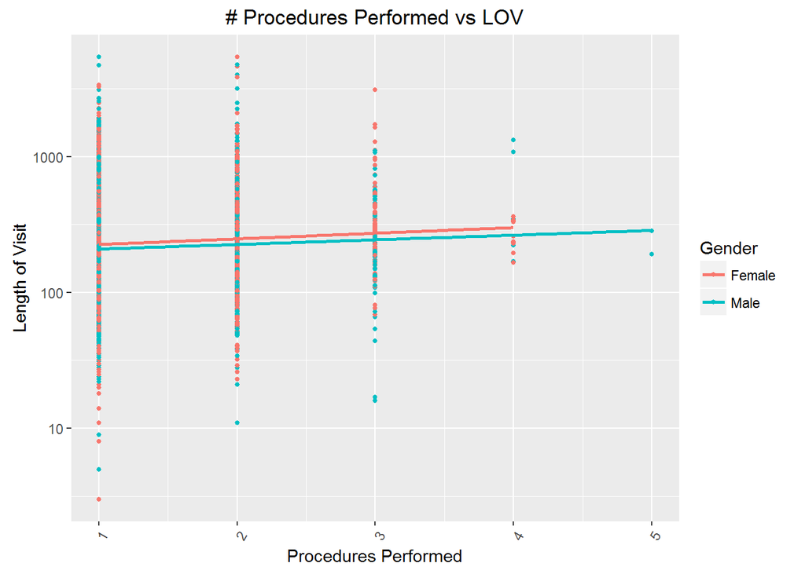

```
##
## Call:
## lm(formula = log(LOV) ~ TOTPROC, data = .)
##
## Residuals:
##     Min      1Q  Median      3Q     Max
## -4.5316 -0.4223  0.0389  0.4510  3.2880
##
## Coefficients:
##             Estimate Std. Error t value Pr(>|t|)
## (Intercept) 5.224767   0.007516 695.179   <2e-16 ***
## TOTPROC     0.041726   0.004186   9.967   <2e-16 ***
## ---
## Signif. codes:  0 '***' 0.001 '**' 0.01 '*' 0.05 '.' 0.1 ' ' 1
##
## Residual standard error: 0.7261 on 9854 degrees of freedom
## Multiple R-squared:  0.009981,   Adjusted R-squared:  0.00988
## F-statistic: 99.34 on 1 and 9854 DF,  p-value: < 2.2e-16
```

```
##
## Call:
## lm(formula = log(LOV) ~ TOTPROC, data = .)
##
## Residuals:
##     Min      1Q  Median      3Q     Max
## -3.5887 -0.4619  0.0365  0.4855  3.4018
##
## Coefficients:
##             Estimate Std. Error t value Pr(>|t|)
## (Intercept) 5.172968   0.009814 527.081  < 2e-16 ***
## TOTPROC     0.025148   0.005129   4.903 9.69e-07 ***
## ---
## Signif. codes:  0 '***' 0.001 '**' 0.01 '*' 0.05 '.' 0.1 ' ' 1
##
## Residual standard error: 0.7612 on 6231 degrees of freedom
## Multiple R-squared:  0.003843,   Adjusted R-squared:  0.003683
## F-statistic: 24.04 on 1 and 6231 DF,  p-value: 9.688e-07
```

# Admission to Hospital from ER

Now we would like to get an overview of what happens to the patients after they leave the ER. Specifically, how many of them are admitted to the hospital - for each of our most common complaints ? Specifically are there any gender differences ?

# Gender and Diagnosis

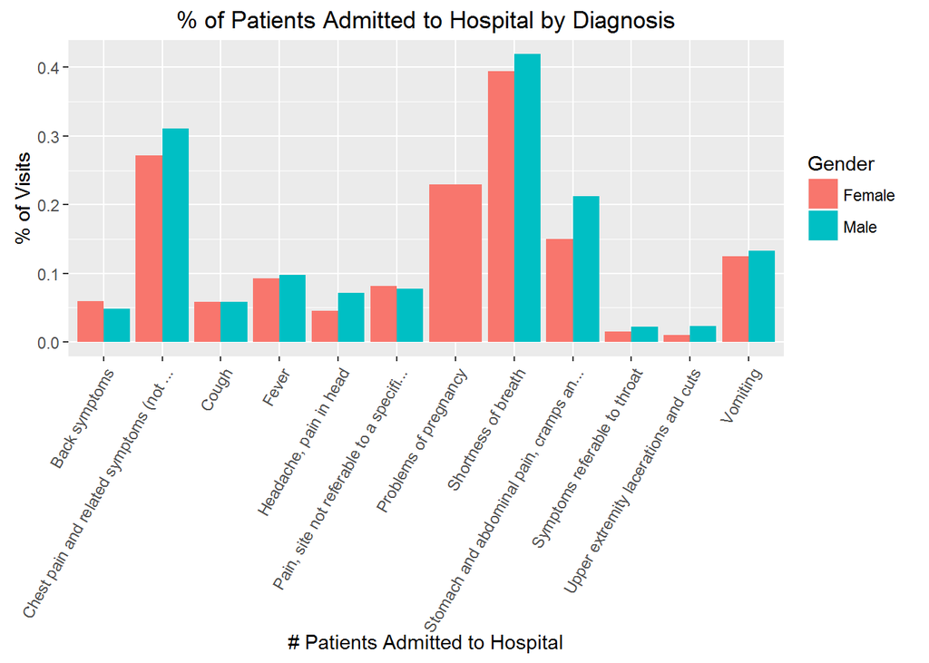

Even though more women than men are typically seen in the ER for many of these complaints, for many symptoms, a larger fraction of men than women are admitted to the hospital. This difference is particularly dramatic looking at abdominal pain, head pain, and chest pain.

# Age

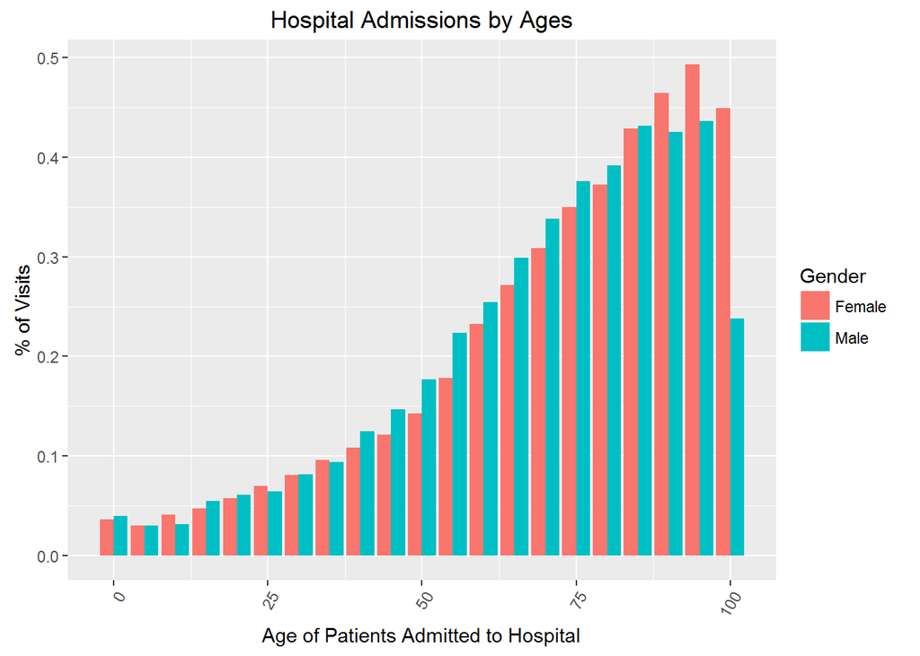

# Race

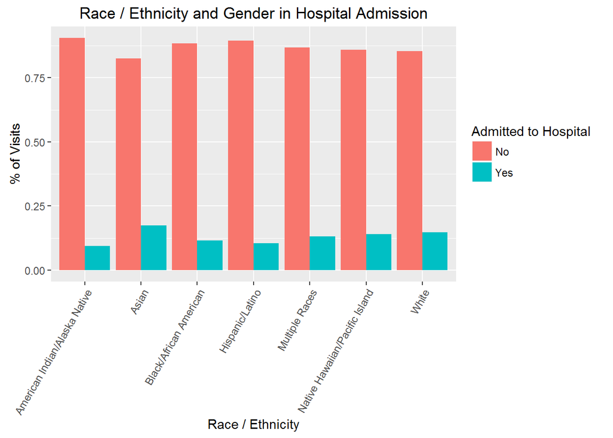

Several studies have shown that hospital admissions secondary to ER visits can boost ER profitability. So we want to create a model that can predict hospital admissions based on ER metrics. We will limit the chief complaint to the top 12 most common (as identified earlier). Our training set will include all the data we have analyzed so far from 2007-2011. Our testing data will be cases from 2006 (which were not used as part of our previous analyses).

# Building Predictive Models for Hospital Admissions

Let’s build a naive model first. We will predict that the probability of hospital admission for each patient is the same as the global probability of a patient being admitted.

```
## The RMSE for a naive model is :  0.3562964
```

To build our first real model, we will perform a logistic regression. There is a lot of correlations amongst our variables, so we will start with a simple model first. Admission is our binary output variable. Our input variables are gender (binary), age(continuous), and chief complaint. For reasons of sanity, we will restrict our analyses (as we have in the past) to the top 12 most common complaint categories.

[output not shown]

Now let us see how well this data predicts hospital admissions.

```
## Using a Logistic Regression model with 3 variables (age, gender, chief complaint), we get an RMSE of :  0.3236418
```

```
## Using a Logistic Regression model with 5 variables (age, gender, chief complaint, race, ethnicity), we get an RMSE of :  0.3238849
```

[output not shown]

With this model, we a slight improvement over the naive model. The strongest factor is the chief complaint.

Now we will add age interaction factors to see if this improves our model

```
## Using a Logistic Regression model with 3 variables (age, gender, chief complaint) and Age interactions, we get an RMSE of :  0.3230221
```

Well that didn’t seem to help much. Maybe lets see if gender interacts with the other 2 variables

```
## Using a Logistic Regression model with 3 variables (age, gender, chief complaint) and gender interactions, we get an RMSE of :  0.323531
```

No improvement there either. Since adding interactions didn’t help much, let’s play around a few more ways - let’s see what happens if we try to predict hospitalizations using only chief complaint.

```
## Using a Logistic Regression model with 1 variable (chief complaint), we get an RMSE of :  0.3407313
```

Well it’s a little better than the naive model but worse than the 3 variable models.

Lets see if we get any significant improvement by adding ETHNICITY and RACE, and the #ofMeds, #ofTests & #ofProcedures to our model.

```
## Out of Sample RMSE for Logistic Regression model with 8 variables (age, gender, chief complaint, ethnicity, race, #med, #diagnostics, #procedures) :  0.3694617  for the test data
```

```
## In Sample RMSE for Logistic Regression model with 8 variables (age, gender, chief complaint, ethnicity, race, #med, #diagnostics, #procedures) :  0.3096667  for the training data
```

This model is overfit - it is better at predicting the training data than the test data.

Finally lets see if we can predict whether a patient with a specific complaint (abdominal / stomach pain) will be admitted to the hospital. We will take our best model so far and remove the complaint variable from the model. Let’s see how well it works :-)

```
## Using a naive model, we get an RMSE of :  0.3790997  for the test data
```

```
## Using a Logistic Regression model with 2 variables (age, gender), we get an RMSE of :  0.3685347  for the test data
```

```
## Out-of-sample RMSE for Logistic Regression model with 7 variables (age, gender, race, ethnicity, meds, diagnostics, procedures) :  0.4185825  for the test data
```

```
## In-sample RMSE for Logistic Regression model with 7 variables (age, gender, race, ethnicity, meds, diagnostics, procedures) :  0.353045  for the test data
```

For the most common complaint in adults (stomach / abdominal pain), it looks like a model based on age and gender give only a slight improvement over the naive model.  
And if we include additional variables, our RMSE is worse than the naive model - it looks like we may be overfitting the data with this many variables. .

Just to convince ourselves, let’s try this one more time with another common complaint - fever.

[output not shown]

```
## Using a Logistic Regression model with 2 variables (age, gender), we get an RMSE of :  0.2839112  for the test data
```

```
## Out-of-Sample Logistic Regression model with 7 variables (age, gender, race, ethnicity, meds, diagnostics, procedures), we get an RMSE of :  0.3556822  for the test data
```

```
## In-Sample RMSE for Logistic Regression model with 7 variables (age, gender, race, ethnicity, meds, diagnostics, procedures) :  0.2358999  for the test data
```